# PRA2 - Tipología y ciclo de vida de dato

### *Alumnos: Omar Mendo Mesa y Guzmán Gómez Pérez*

## Índice

1. Descripción del dataset. ¿Por qué es importante y qué pregunta/problema pretende responder?
2. Integración y selección de los datos de interés a analizar.
3. Limpieza de los datos.

3.1. ¿Los datos contienen ceros o elementos vacíos? ¿Cómo gestionarías cada uno de estos casos?

3.2. Identificación y tratamiento de valores extremos.

4. Análisis de los datos.

4.1. Selección de los grupos de datos que se quieren analizar/comparar (planificación de los análisis a aplicar).

4.2. Comprobación de la normalidad y homogeneidad de la varianza.

4.3. Aplicación de pruebas estadísticas para comparar los grupos de datos. En función de los datos y el objetivo del estudio, aplicar pruebas de contraste de hipótesis, correlaciones, regresiones, etc. Aplicar al menos tres métodos de análisis diferentes.

5. Representación de los resultados a partir de tablas y gráficas.
6. Resolución del problema. A partir de los resultados obtenidos, ¿cuáles son las conclusiones? ¿Los resultados permiten responder al problema?

#### 1. Descripción del dataset. ¿Por qué es importante y qué pregunta/problema pretende

Este conjunto de datos contiene la información de los pasajeros del Titanic, aquel mítico ferri que naufragó el 15 de abril de 1912, durante su viaje inaugural, después de chocar con un iceberg. Desafortunadamente, murieron 1502 de los 2224 pasajeros y la tripulaciónm debido a la escasez de botes salvavidas y las frias temperaturas del oceano.

Este documento estudia, a través de las herramientas de integración si existió algún patrón entre los afortundados supervivientes.

**1.1 Carga del dataset:**

```r
#getwd()
setwd("~/Desktop/Máster UOC/Tipología y ciclo de vida de datos/bloque 2/Titanic_data_analysis_R/data")
train_df <- read.csv(file="train.csv",head=TRUE,sep=",")
test_df <- read.csv(file="test.csv",head=TRUE,sep=",")

head(train_df,11)
```

|  | PassengerId | Survived | Pclass | Name | Sex | Age | SibSp | Parch | Ticket | Fare | Cabin | Embarked |
| --- | --- | --- | --- | --- | --- | --- | --- | --- | --- | --- | --- | --- |
| 1 | 1 | 0 | 3 | Braund, Mr. Owen Harris | male | 22 | 1 | 0 | A/5 21171 | 7.2500 |  | S |
| 2 | 2 | 1 | 1 | Cumings, Mrs. John Bradley (Florence Briggs Thayer) | female | 38 | 1 | 0 | PC 17599 | 71.2833 | C85 | C |
| 3 | 3 | 1 | 3 | Heikkinen, Miss. Laina | female | 26 | 0 | 0 | STON/O2. 3101282 | 7.9250 |  | S |
| 4 | 4 | 1 | 1 | Futrelle, Mrs. Jacques Heath (Lily May Peel) | female | 35 | 1 | 0 | 113803 | 53.1000 | C123 | S |
| 5 | 5 | 0 | 3 | Allen, Mr. William Henry | male | 35 | 0 | 0 | 373450 | 8.0500 |  | S |
| 6 | 6 | 0 | 3 | Moran, Mr. James | male | NA | 0 | 0 | 330877 | 8.4583 |  | Q |
| 7 | 7 | 0 | 1 | McCarthy, Mr. Timothy J | male | 54 | 0 | 0 | 17463 | 51.8625 | E46 | S |
| 8 | 8 | 0 | 3 | Palsson, Master. Gosta Leonard | male | 2 | 3 | 1 | 349909 | 21.0750 |  | S |
| 9 | 9 | 1 | 3 | Johnson, Mrs. Oscar W (Elisabeth Vilhelmina Berg) | female | 27 | 0 | 2 | 347742 | 11.1333 |  | S |
| 10 | 10 | 1 | 2 | Nasser, Mrs. Nicholas (Adele Achem) | female | 14 | 1 | 0 | 237736 | 30.0708 |  | C |

[output cut: 1 more lines]

**1.2 Descripción de atributos:**

**Embarked**: Puerto de embarcación:

- C = Cherbourg.
- Q = Queenstown.
- S = Southampton

**Cabin**: Nº de cabina.

**Fare**: Tarifa del pasajero.

**Ticket**: Número (Id) del ticket de embarcación.

**Sex**: Género del tripulante.

- 1 si es hombre.
- 0 si es mujer.

**Survival**: Categórica. Potencial etiqueta supervisada de los modelos regresivo:

- 1 si sobrevivió
- 0 si no sobrevivió

**pclass**: Categórica. Aproximación del estado socio-económico (ticket que pagaron para el viaje):

- 1st = Upper
- 2nd = Middle
- 3rd = Lower

**age**: Numérico. Fraccional en caso de ser inferior a 1.

**sibsp**: Categórica. Nº de parientes directos (horizontal): de tipo hermanos, hermanastros o esposos (marido o mujer).

**parch**: Categórica. Nº de parientes directos (vertical); de tipo padre/madre, hijos, hijastros o nietos.

- 0 si el niño viajaba con una cuidadora.

### 2. Integración y selección de los datos de interés a analizar.__

**2.1 Exploración del tipado de los atributos:**

```r
str(train_df)
```

```
## 'data.frame':    891 obs. of  12 variables:
##  $ PassengerId: int  1 2 3 4 5 6 7 8 9 10 ...
##  $ Survived   : int  0 1 1 1 0 0 0 0 1 1 ...
##  $ Pclass     : int  3 1 3 1 3 3 1 3 3 2 ...
##  $ Name       : Factor w/ 891 levels "Abbing, Mr. Anthony",..: 109 191 358 277 16 559 520 629 417 581 ...
##  $ Sex        : Factor w/ 2 levels "female","male": 2 1 1 1 2 2 2 2 1 1 ...
##  $ Age        : num  22 38 26 35 35 NA 54 2 27 14 ...
##  $ SibSp      : int  1 1 0 1 0 0 0 3 0 1 ...
##  $ Parch      : int  0 0 0 0 0 0 0 1 2 0 ...
##  $ Ticket     : Factor w/ 681 levels "110152","110413",..: 524 597 670 50 473 276 86 396 345 133 ...
##  $ Fare       : num  7.25 71.28 7.92 53.1 8.05 ...
##  $ Cabin      : Factor w/ 148 levels "","A10","A14",..: 1 83 1 57 1 1 131 1 1 1 ...
##  $ Embarked   : Factor w/ 4 levels "","C","Q","S": 4 2 4 4 4 3 4 4 4 2 ...
```

Algunos de los datos deberían ser categóricos y no numéricos, por ejemplo:

```r
train_df$Survived <- as.factor(train_df$Survived)
train_df$Pclass <- as.factor(train_df$Pclass)
train_df$SibSp <- as.factor(train_df$SibSp)
train_df$Parch <- as.factor(train_df$Parch)
```

Esto se debe a que sus valores son representativos de subgrupos y no de una magnitud numérica medible.

Y otros, son categóricos y deberían ser caracteres (string).

Los valores del atributo Cabin, están compuestos por combinaciones de caracteres y números, contienen cierto orden del que podría extraerse información, ya que este puede abstraer la distribución (localización) de las cabinas en zonas del barco.

```r
train_df$Cabin <- as.character(train_df$Cabin)
```

La distribución y el tipado final quedaría del siguiente modo:

```r
str(train_df)
```

```
## 'data.frame':    891 obs. of  12 variables:
##  $ PassengerId: int  1 2 3 4 5 6 7 8 9 10 ...
##  $ Survived   : Factor w/ 2 levels "0","1": 1 2 2 2 1 1 1 1 2 2 ...
##  $ Pclass     : Factor w/ 3 levels "1","2","3": 3 1 3 1 3 3 1 3 3 2 ...
##  $ Name       : Factor w/ 891 levels "Abbing, Mr. Anthony",..: 109 191 358 277 16 559 520 629 417 581 ...
##  $ Sex        : Factor w/ 2 levels "female","male": 2 1 1 1 2 2 2 2 1 1 ...
##  $ Age        : num  22 38 26 35 35 NA 54 2 27 14 ...
##  $ SibSp      : Factor w/ 7 levels "0","1","2","3",..: 2 2 1 2 1 1 1 4 1 2 ...
##  $ Parch      : Factor w/ 7 levels "0","1","2","3",..: 1 1 1 1 1 1 1 2 3 1 ...
##  $ Ticket     : Factor w/ 681 levels "110152","110413",..: 524 597 670 50 473 276 86 396 345 133 ...
##  $ Fare       : num  7.25 71.28 7.92 53.1 8.05 ...
##  $ Cabin      : chr  "" "C85" "" "C123" ...
##  $ Embarked   : Factor w/ 4 levels "","C","Q","S": 4 2 4 4 4 3 4 4 4 2 ...
```

Terminamos con un resumen de los indicadores estadísticos de cada atributo; cuartiles, media, mediana, maximo y minimo para los numéricos. Distribución de valores para los factores. Cantidad de observaciones para los caracteres.

```r
summary(train_df)
```

```
##   PassengerId    Survived Pclass                                     Name
##  Min.   :  1.0   0:549    1:216   Abbing, Mr. Anthony                  :  1
##  1st Qu.:223.5   1:342    2:184   Abbott, Mr. Rossmore Edward          :  1
##  Median :446.0            3:491   Abbott, Mrs. Stanton (Rosa Hunt)     :  1
##  Mean   :446.0                    Abelson, Mr. Samuel                  :  1
##  3rd Qu.:668.5                    Abelson, Mrs. Samuel (Hannah Wizosky):  1
##  Max.   :891.0                    Adahl, Mr. Mauritz Nils Martin       :  1
##                                   (Other)                              :885
##      Sex           Age        SibSp   Parch        Ticket         Fare
##  female:314   Min.   : 0.42   0:608   0:678   1601    :  7   Min.   :  0.00
##  male  :577   1st Qu.:20.12   1:209   1:118   347082  :  7   1st Qu.:  7.91
##               Median :28.00   2: 28   2: 80   CA. 2343:  7   Median : 14.45
##               Mean   :29.70   3: 16   3:  5   3101295 :  6   Mean   : 32.20
##               3rd Qu.:38.00   4: 18   4:  4   347088  :  6   3rd Qu.: 31.00
##               Max.   :80.00   5:  5   5:  5   CA 2144 :  6   Max.   :512.33
##               NA's   :177     8:  7   6:  1   (Other) :852
##     Cabin           Embarked
##  Length:891          :  2
##  Class :character   C:168
##  Mode  :character   Q: 77
##                     S:644
##
##
##
```

Podemos sacar conclusiones de interés, como:

- Había 263 hombres más que mujeres (lo cual probablemente repercuta en las regresiones al asumir que el hombre tenía más probabilidades de no sobrevivir).
- La edad media de los tripulantes era de 30 años aproximadamente. El más anciano tenía 80 años y el más jóven tenía 4 meses y medio. El 50% de la población oscilaba entre los 20 y los 38 años.

### 3. Limpieza de los datos.__

**3.1. ¿Los datos contienen ceros o elementos vacíos? ¿Cómo gestionarías cada uno de estos casos?**

Investigamos ahora qué cantidad de valores asuentes o vacíos hay en cada atributo.

Para el único atributo de tipo String, deberemos considerar los caracteres vacíos como valores ausentes también. En los factores no es necesario puesto que se podrían considerar una categoría más.

```r
train_df$Cabin[train_df$Cabin==""] <- NA
train_df$Cabin[train_df$Cabin==" "] <- NA
```

```r
sapply(train_df, function(x) sum(is.na(x)))
```

```
## PassengerId    Survived      Pclass        Name         Sex         Age
##           0           0           0           0           0         177
##       SibSp       Parch      Ticket        Fare       Cabin    Embarked
##           0           0           0           0         687           0
```

Son demasiados registros como para eliminarlos. Para imputar estos valores se podría aplicar un clustering por k Nearest Neighbourgs, reemplazando el valor nulo por el valor de las observaciones (pasajeros). Por ejemplo, aquellos que tengan un parentesco similar, es muy probable que tengan un rango de edad similar.

```r
#install.packages('VIM')
library(VIM)
train_df$Age <- kNN(train_df)$Age
```

El caso de la cabina no tiene sentido inferirlo por clustering. Ya que ningún atributo correlacciona apropiadamente este valor. En cambio, se sustituirá por un valor común, que podrá ser útil en caso de que estos pasajeros sin cabina, guardaran algún tipo de vinculo.

```r
train_df$Cabin[is.na(train_df$Cabin)] <- "Sin cabina"
```

**3.2. Identificación y tratamiento de valores extremos.**

Veamos qué valores numéricos marginales puede haber en los atributos numéricos Age y Fare. Estos valores pueden aparecer por errores de inserción o por ser observaciones anómalas; se eliminarán para tratar de conseguir unas regresiones que generalicen lo mejor posible.

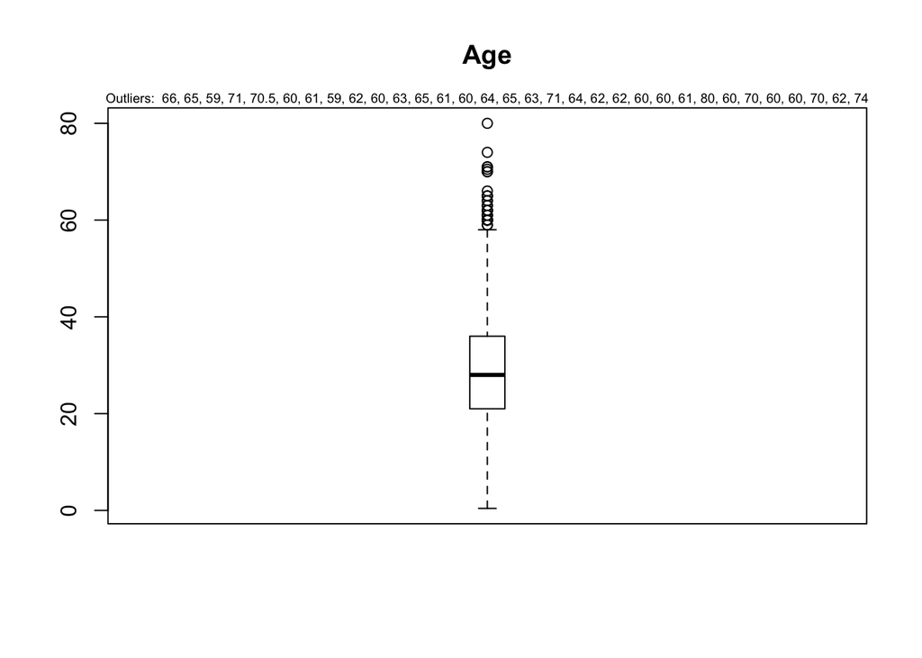

```r
outlier_values <- boxplot.stats(train_df$Age)$out
boxplot(train_df$Age, main="Age", boxwex=0.1)
mtext(paste("Outliers: ", paste(outlier_values, collapse=", ")), cex=0.6)
```

```r
train_df <- train_df[-which(train_df$Age %in% outlier_values),] # los eliminamos
```

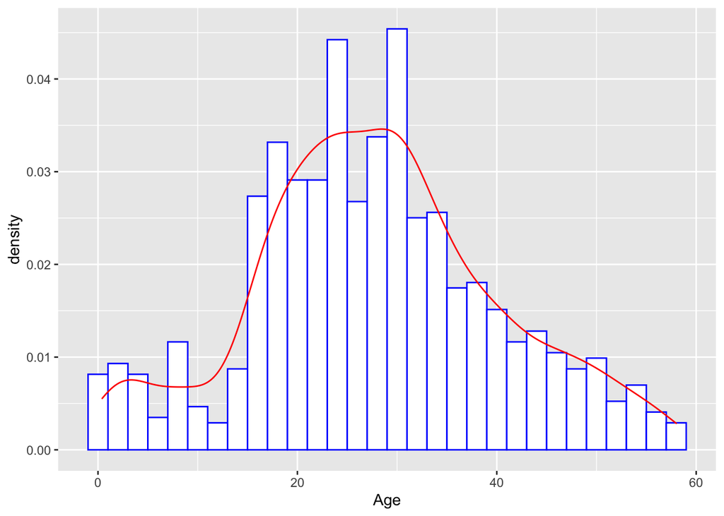

```r
library(ggplot2)
ggplot(train_df, aes(x = Age)) + geom_histogram(aes(y = ..density..), binwidth=2, color='blue', fill="white") + geom_density(color='red')
```

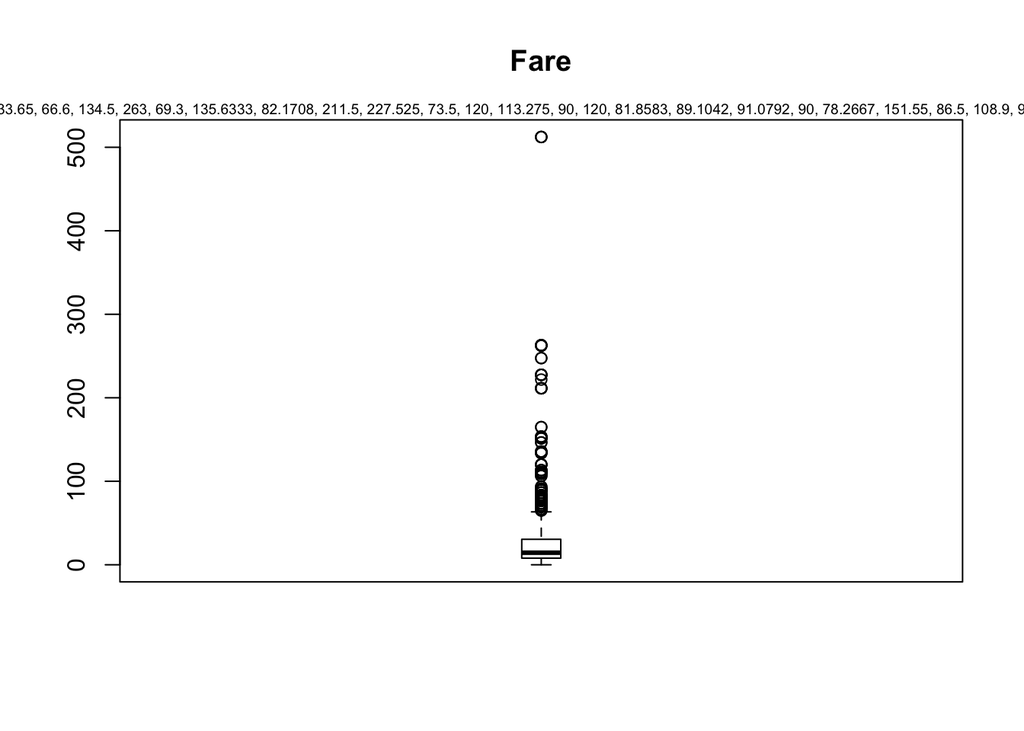

```r
outlier_values <- boxplot.stats(train_df$Fare)$out
boxplot(train_df$Fare, main="Fare", boxwex=0.1)
mtext(paste("Outliers: ", paste(outlier_values, collapse=", ")), cex=0.6)
```

```r
train_df <- train_df[-which(train_df$Fare %in% outlier_values),] # los eliminamos
```

Por lo visto, era extraño que el ticket superara el coste de los 70 dolares. Los costes más altos se deberían o bien a errores o bien a Cabinas con unas condiciones privilegiadas. Y por lo visto, no era raro pasar gratis, ya que el cero lo considera un valor común más.

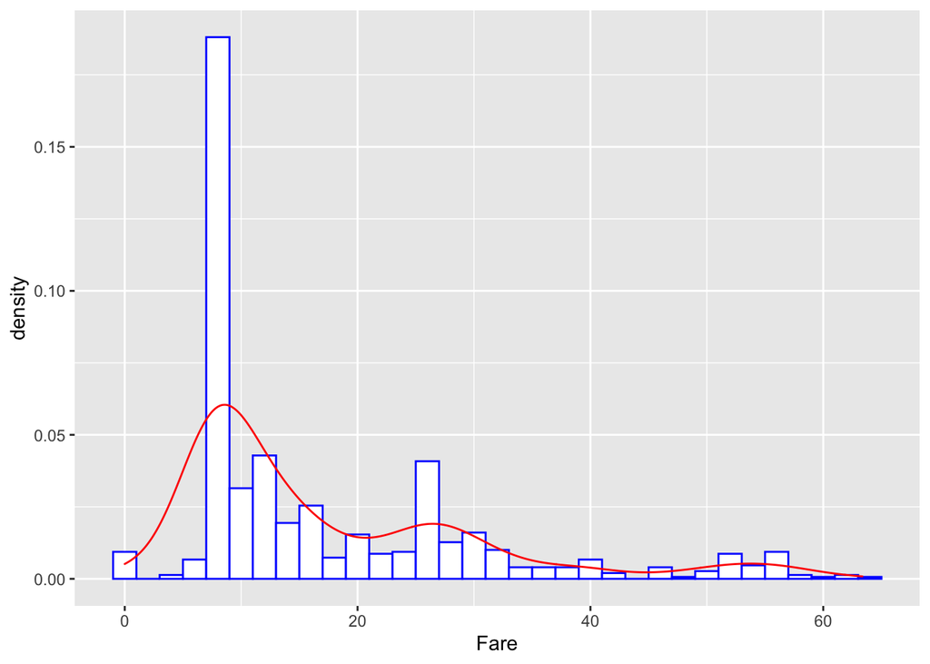

```r
ggplot(train_df, aes(x = Fare)) + geom_histogram(aes(y = ..density..), binwidth=2, color='blue', fill="white") + geom_density(color='red')
```

### 4. Análisis de los datos.

**4.1. Selección de los grupos de datos que se quieren analizar/comparar (planificación de los análisis a aplicar).**

El nombre es prescindible puesto que ya tenemos un identificador ya. Aun así, podrían llegar a deducirse información útil como la nacionalidad (aproximada) del pasajero. Pero esta tarea no aplica al alcance de esta tarea.

```r
train_df$Name <- NULL
```

Del mismo modo, podríamos asumir que el ticket se trata del identificador del tripulante y que no contiene otro tipo de información deducible o complementaria, más allá del orden de compra del ticket, lo cual, dificilmente interviene en la supervivencia del pasajero. Además, ya tenemos un ID por lo que prescindiremos del atributo.

```r
train_df$Ticket <- NULL
```

**4.2. Comprobación de la normalidad y homogeneidad de la varianza.**

Veamos si los atributos numéricos Age y Fare siguen una distribución normal.

Ahora aplicaremos el **test de Shapiro** para confirmar esta distribución:

```r
alpha = 0.05
shapiro.test(train_df$Age)$p.value > alpha
```

```
## [1] FALSE
```

```r
alpha = 0.05
shapiro.test(train_df$Fare)$p.value > alpha
```

```
## [1] FALSE
```

Por otro lado, utilizamos el gráfico Q-Q, para diagnosticar la desviación de los datos de la muestra en relación con una población normal:

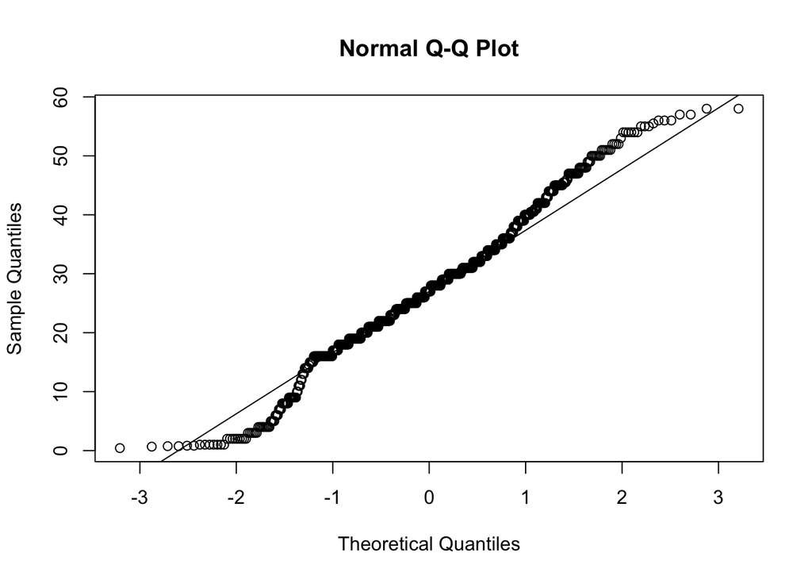

```r
qqnorm(train_df$Age)
qqline(train_df$Age)
```

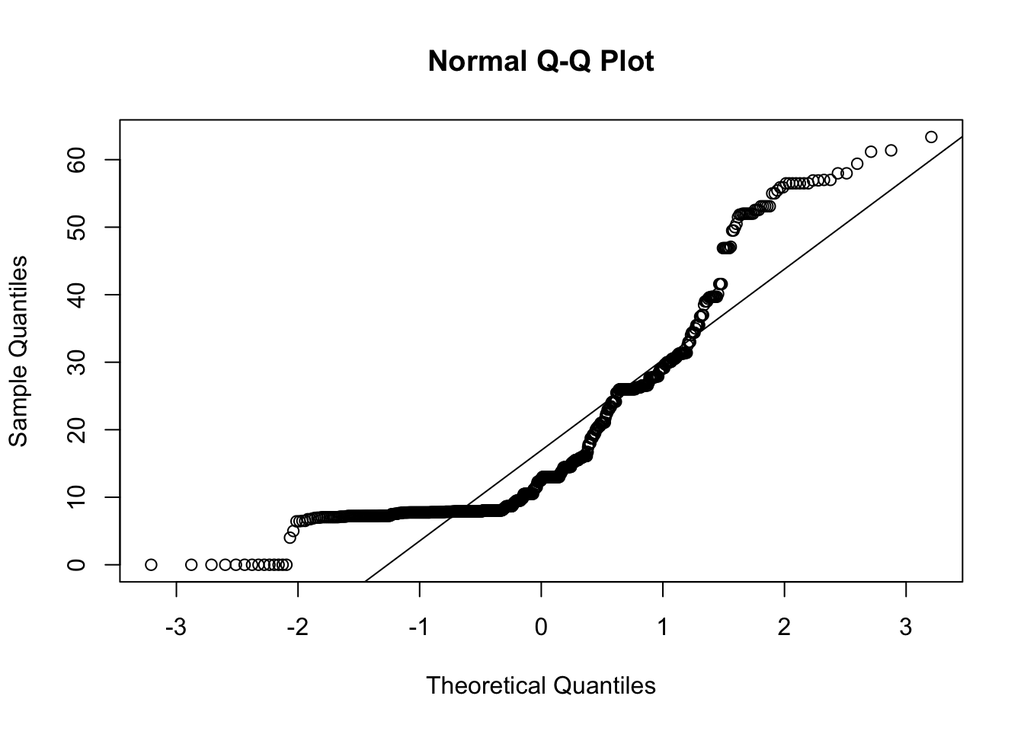

```r
qqnorm(train_df$Fare)
qqline(train_df$Fare)
```

**4.3. Aplicación de pruebas estadísticas para comparar los grupos de datos. En función de los datos y el objetivo del estudio, aplicar pruebas de contraste de hipótesis, correlaciones, regresiones, etc. Aplicar al menos tres métodos de análisis diferentes.**

**Correlaciones:**

Para comenzar con la aplicación de pruebas estadísticas sobre nuestro conjunto de datos, usaremos una **matriz de correlación** para poder observar o seleccionar las variables que sean de mayor interés o que nos arrojen algún resultado esclarecedor de si alguna de las variables descritas en nuestro dataset, infiere sobre la probabilidad de supervivencia.

Además, la variable **Embarked** debenmos modificarla de la misma manera que **Sex**, por lo que la modificación de realizará de la siguiente manera:

- Cherbourg(**C**) = 0
- Queenstown(**Q**) = 1
- Southampton(**S**) = 2

```r
# Creamos un nuevo conjunto de datos a partir del original (solo para esta prueba)
train_df_corr <- train_df

# Realizamos las modificaciones descritas anteriormente
train_df_corr$Sex[train_df_corr$Sex=='male'] <- 0
train_df_corr$Sex[train_df_corr$Sex=='female'] <- 1
train_df_corr$Embarked[train_df_corr$Embarked=='C'] <- 0
train_df_corr$Embarked[train_df_corr$Embarked=='Q'] <- 1
train_df_corr$Embarked[train_df_corr$Embarked=='S'] <- 2
train_df_corr$Survived <- as.numeric(train_df_corr$Survived)
train_df_corr$Pclass <- as.numeric(train_df_corr$Pclass)
train_df_corr$Sex <- as.numeric(train_df_corr$Sex)
train_df_corr$Age <- as.numeric(train_df_corr$Age)
train_df_corr$SibSp <- as.numeric(train_df_corr$SibSp)
train_df_corr$Parch <- as.numeric(train_df_corr$Parch)
train_df_corr$Fare <- as.numeric(train_df_corr$Fare)
train_df_corr$Embarked <- as.numeric(train_df_corr$Embarked)

train_df_corr$Cabin <- NULL
train_df_corr$PassengerId <- NULL

head(train_df_corr, 10)
```

|  | Survived | Pclass | Sex | Age | SibSp | Parch | Fare | Embarked |
| --- | --- | --- | --- | --- | --- | --- | --- | --- |
| 1 | 1 | 3 | NA | 22.0 | 2 | 1 | 7.2500 | NA |
| 3 | 2 | 3 | NA | 26.0 | 1 | 1 | 7.9250 | NA |
| 4 | 2 | 1 | NA | 35.0 | 2 | 1 | 53.1000 | NA |
| 5 | 1 | 3 | NA | 35.0 | 1 | 1 | 8.0500 | NA |
| 6 | 1 | 3 | NA | 40.5 | 1 | 1 | 8.4583 | NA |
| 7 | 1 | 1 | NA | 54.0 | 1 | 1 | 51.8625 | NA |
| 8 | 1 | 3 | NA | 2.0 | 4 | 2 | 21.0750 | NA |
| 9 | 2 | 3 | NA | 27.0 | 1 | 3 | 11.1333 | NA |
| 10 | 2 | 2 | NA | 14.0 | 2 | 1 | 30.0708 | NA |
| 11 | 2 | 3 | NA | 4.0 | 2 | 2 | 16.7000 | NA |

Una vez realizadas las transformaciones previas a nuestro nuevo conjunto de datos (únicamente para esta prueba), aplicaremos el *test de Spearman* para poder calcular las correlaciones entre pares de variables.

```r
# Aplicamos el test de Spearman
corr_res <- cor(train_df_corr, method="spearman")
corr_res
```

```
##            Survived      Pclass Sex         Age       SibSp       Parch
## Survived  1.0000000 -0.28134904  NA -0.12400687  0.07314080  0.15495698
## Pclass   -0.2813490  1.00000000  NA -0.36380384  0.01158735  0.02767919
## Sex              NA          NA   1          NA          NA          NA
## Age      -0.1240069 -0.36380384  NA  1.00000000 -0.22802158 -0.30368610
## SibSp     0.0731408  0.01158735  NA -0.22802158  1.00000000  0.46916106
## Parch     0.1549570  0.02767919  NA -0.30368610  0.46916106  1.00000000
## Fare      0.2587331 -0.55783246  NA  0.08104727  0.47421689  0.44168118
## Embarked         NA          NA  NA          NA          NA          NA
##                 Fare Embarked
## Survived  0.25873309       NA
## Pclass   -0.55783246       NA
## Sex               NA       NA
## Age       0.08104727       NA
## SibSp     0.47421689       NA
## Parch     0.44168118       NA
## Fare      1.00000000       NA
## Embarked          NA        1
```

A continuación, realizaremos una representación gráfica de nuestra matriz de correlación, donde podremos observar qué variables están correlacionadas con otras.

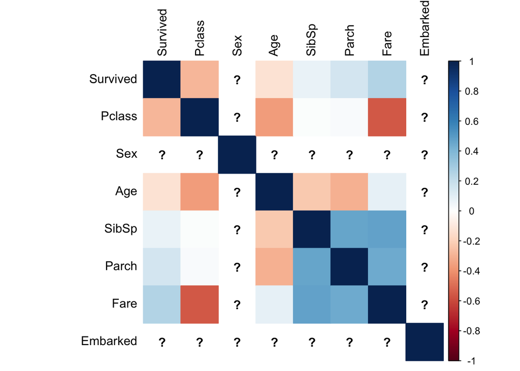

```r
# Aplicamos el test de Spearman
library(corrplot)
corrplot(corr_res, method="color", tl.col = "black")
```

Además, se observa un grupo de correlación entre diversas variables sobre **Parch** que, como sabemos del análisis previo de nuestro conjunto de datos, viene dado por el número de parientes directos (de tipo vertical, como pueden ser padres, hijos, nietos…)

Como vemos, la variable **Parch** esta correlacionada con la variable **SibSp**, que a simple vista, podemos deducir que, al tratarse de número de parientes directos (tanto en vertical como en horizontal), estas variables van a ir normalmente de la mano para cada pasajero

Así como la variable **Fare**, que esta correlacionada con las variables anteriormente descritas, **SibSp** y **Fare**.

**Contraste de hipótesis:**

```r
alpha = 0.05
shapiro.test(train_df$Fare[ train_df$Survived==1 ])$p.value > alpha
```

```
## [1] FALSE
```

```r
alpha = 0.05
shapiro.test(train_df$Fare[ train_df$Survived==0 ])$p.value > alpha
```

```
## [1] FALSE
```

```r
t.test(train_df$Fare[ train_df$Survived==1 ], train_df$Fare[ train_df$Survived==0 ],alternative="greater", var.equal=FALSE)
```

```
##
##  Welch Two Sample t-test
##
## data:  train_df$Fare[train_df$Survived == 1] and train_df$Fare[train_df$Survived == 0]
## t = 6.4296, df = 428.7, p-value = 1.709e-10
## alternative hypothesis: true difference in means is greater than 0
## 95 percent confidence interval:
##  5.095916      Inf
## sample estimates:
## mean of x mean of y
##  21.99375  15.14090
```

```r
glm.fit <- lm(as.numeric(Survived) ~ Pclass + Sex + Age + SibSp + Parch + Fare + Cabin + Embarked, data = train_df)
summary(glm.fit)
```

```
##
## Call:
## lm(formula = as.numeric(Survived) ~ Pclass + Sex + Age + SibSp +
##     Parch + Fare + Cabin + Embarked, data = train_df)
##
## Residuals:
##      Min       1Q   Median       3Q      Max
## -0.81570 -0.16736 -0.06338  0.16424  1.06002
##
## Coefficients:
##                   Estimate Std. Error t value Pr(>|t|)
## (Intercept)       1.549287   0.383652   4.038 6.03e-05 ***
## Pclass2          -0.070008   0.102400  -0.684  0.49443
## Pclass3          -0.212683   0.104888  -2.028  0.04300 *
## Sexmale          -0.456888   0.033951 -13.457  < 2e-16 ***
## Age              -0.008619   0.001543  -5.585 3.45e-08 ***
## SibSp1           -0.047497   0.042155  -1.127  0.26028
## SibSp2           -0.115644   0.092222  -1.254  0.21030
## SibSp3           -0.524838   0.113775  -4.613 4.79e-06 ***
## SibSp4           -0.424583   0.107691  -3.943 8.94e-05 ***
## SibSp5           -0.534149   0.189049  -2.825  0.00487 **
## Parch1            0.062410   0.054702   1.141  0.25432
## Parch2           -0.008139   0.069335  -0.117  0.90659
## Parch3            0.084197   0.170547   0.494  0.62169
## Parch4           -0.368687   0.218321  -1.689  0.09175 .
## Parch5           -0.273988   0.174505  -1.570  0.11688
## Parch6           -0.577587   0.379307  -1.523  0.12831
## Fare              0.005430   0.002080   2.611  0.00925 **
## CabinA14          0.128996   0.525890   0.245  0.80631
## CabinA16          0.696892   0.526046   1.325  0.18571
## CabinA19          0.188304   0.525720   0.358  0.72032
## CabinA20          1.068294   0.525315   2.034  0.04240 *
## CabinA24         -0.069699   0.525458  -0.133  0.89452
## CabinA26          1.197502   0.523983   2.285  0.02261 *
## CabinA31          1.084030   0.523349   2.071  0.03872 *
## CabinA32          0.070902   0.525326   0.135  0.89268
## CabinA36          0.273471   0.531359   0.515  0.60696
## CabinA6           0.985877   0.525184   1.877  0.06094 .
## CabinA7           0.223591   0.524289   0.426  0.66991
## CabinB102         0.221755   0.531388   0.417  0.67659
```

[output cut: 61 more lines]

```
## CabinF2           0.644804   0.440117   1.465  0.14339
## CabinF33          0.738852   0.439172   1.682  0.09298 .
## CabinF38          0.305347   0.532864   0.573  0.56682
## CabinF4           0.641875   0.473564   1.355  0.17576
## CabinG6           0.225469   0.427735   0.527  0.59829
## CabinSin cabina   0.434138   0.380963   1.140  0.25488
## CabinT            0.132405   0.524967   0.252  0.80095
## EmbarkedQ         0.040051   0.061174   0.655  0.51289
## EmbarkedS        -0.029716   0.044404  -0.669  0.50360
## ---
## Signif. codes:  0 '***' 0.001 '**' 0.01 '*' 0.05 '.' 0.1 ' ' 1
##
## Residual standard error: 0.3698 on 648 degrees of freedom
## Multiple R-squared:  0.4753, Adjusted R-squared:  0.396
## F-statistic: 5.991 on 98 and 648 DF,  p-value: < 2.2e-16
```

Los atributos que más impacto tienen en el resultado de la supervivencia del naufragio son:

- Sexmale: Los hombres tenían una probabilidad muy alta de no sobrevivir, probablemente porque fueron los últimos en entrar a los botes salvavidas, priorizando a mujeres y niños.
- Age: Cuanto mayor eras, menos probabilidades de supervivencia tenías, muy probablemente, por la misma razón que la anteriormente explicada.
- SibSp3, SibSp4, SibSp5: tener muchos familiares a bordo no era una garantía de supervivencia, probablemente, por tener que priorizarles o perder tiempo velando por su supervivencia durante el naufragio.
- Fare: Haber pagado una tarifa alta contribuía en cierta medida a la supervivencia, probablemente vinculado a la relevancia de esas personas y/o a su prioridad en botes salvavidas, incluida en las condiciones de embarque.
- CabinA20, CabinA26, CabinA31 Algunas cabinas fueron afortunadas, lógicamente por su ubicación, pudieron, quizás, llegar antes a los botes salvavidas.

**5. Representación de los resultados a partir de tablas y gráficas.**

Relación entre el género y la supervivencia:

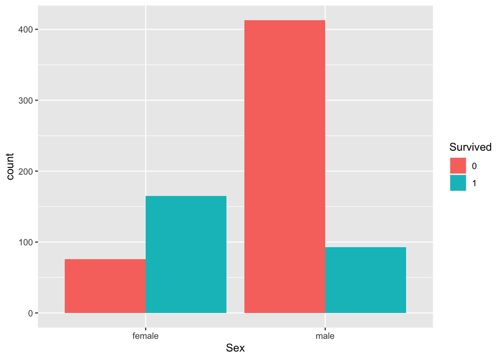

```r
ggplot(train_df, aes(Sex, ..count..)) + geom_bar(aes(fill = Survived), position = "dodge")
```

Confirmamos que ser hombres perjudicaba a la supervivencia.

Relación entre el parenteso “horizontal” y la supervivencia:

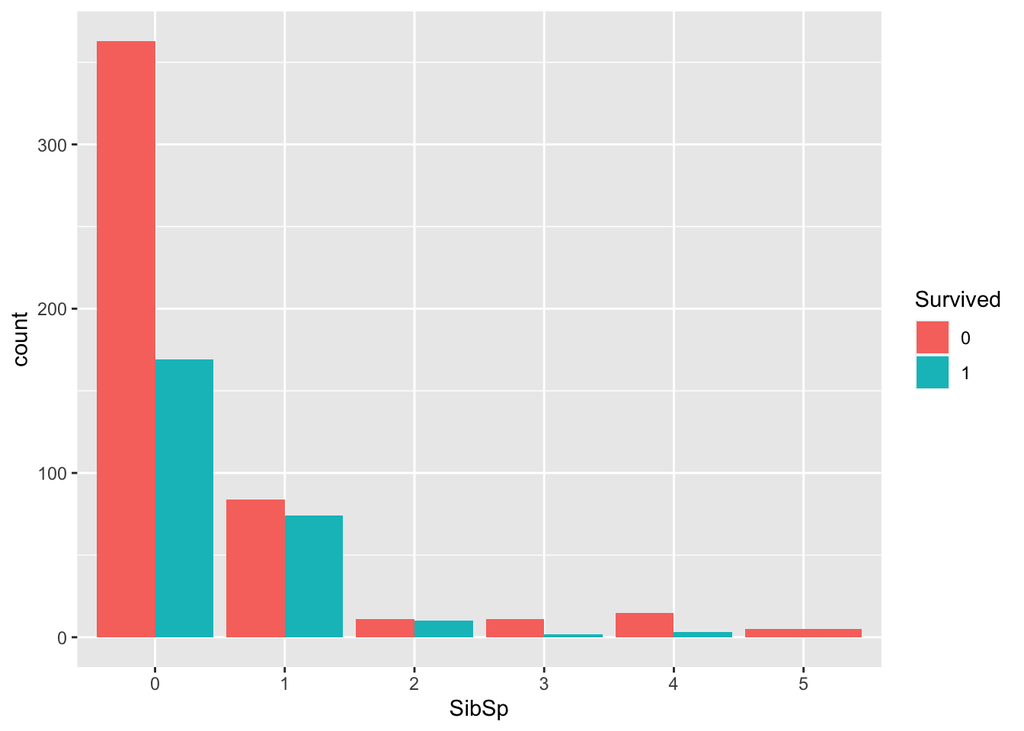

```r
ggplot(train_df, aes(SibSp, ..count..)) + geom_bar(aes(fill = Survived), position = "dodge")
```

Relación entre la edad y la supervivencia:

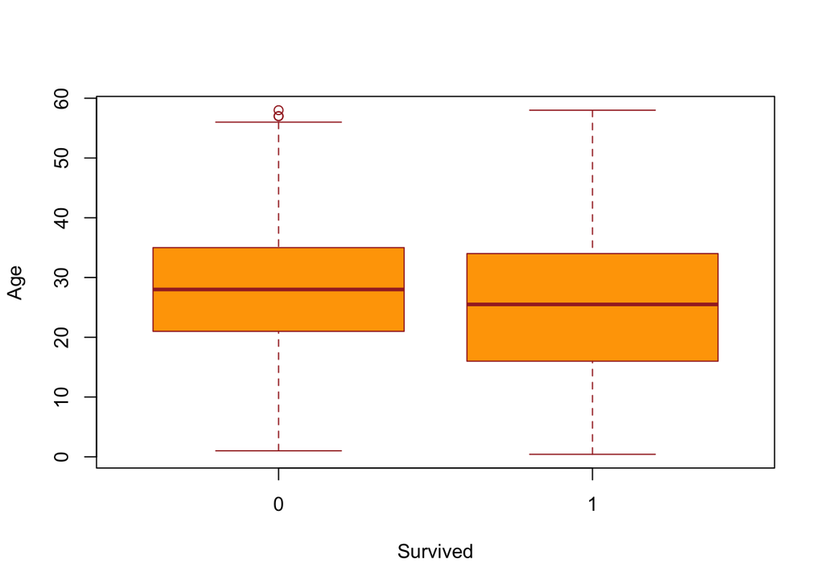

```r
boxplot(Age~Survived,
data=train_df,
xlab="Survived",
ylab="Age",
col="orange",
border="brown"
)
```

Confirmamos que los que sobrevivieron eran algo más jóvenes que los que no, sobre los 25 años de media.

Relación entre la tarifa y la supervivencia:

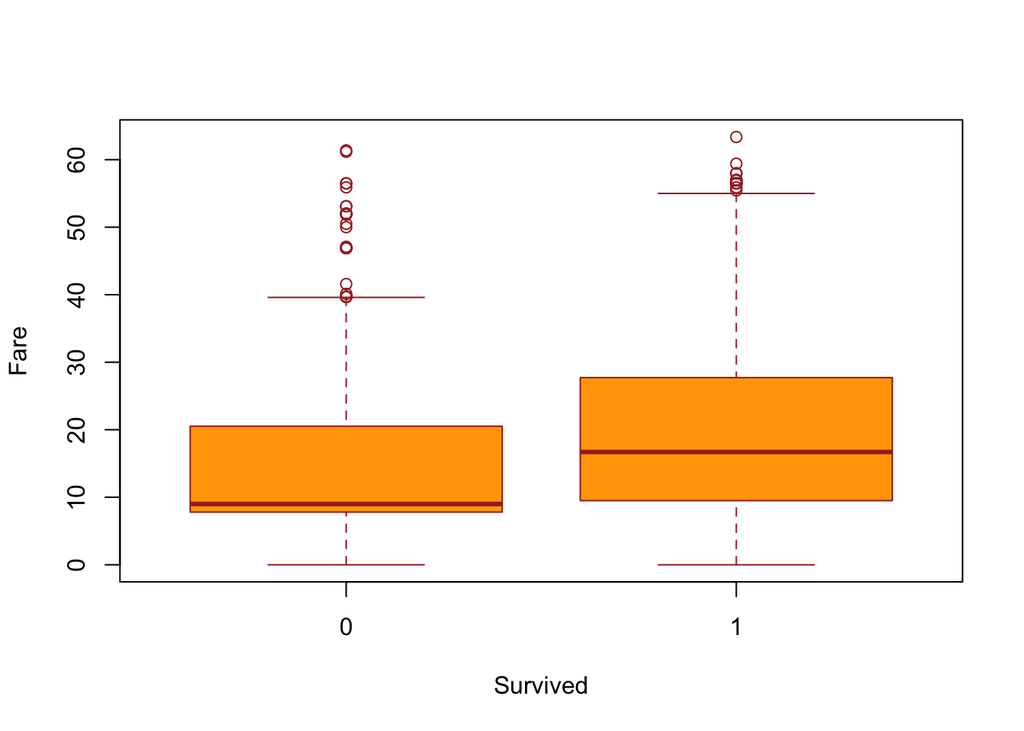

```r
boxplot(Fare~Survived,
data=train_df,
xlab="Survived",
ylab="Fare",
col="orange",
border="brown"
)
```

Confirmamos que los que sobrevivieron también tenían tarifas más caras.

**6. Resolución del problema. A partir de los resultados obtenidos, ¿cuáles son las conclusiones? ¿Los resultados permiten responder al problema?**

Una vez realizados todos los pasos anteriores, podemos sacar como conclusiones los resultados obtenidos de las distintas pruebas estadísticas sobre nuestro conjunto de datos que, a través de diversas *tablas* y *gráficas*, podemos ver las distintas variables que influyeron sobre la probabilidad de sobrevivir al hundimiento del Titanic.

Como primer paso, los datos han sido sometidos a un procesamiento para manejar lso casos de ceros o elementos vacíos y valores extremos (*outliers*).

Otro resultado clarificador, es la **edad**, cuanto mayor era un pasajero, mayores probabilidades de **no sobrevivir** tenía, ya sea por la capacidad de reacción, velocidad o capacidad para poder zafarse de los infortunios antes de tener probabilidades de sobrevivir.

Antes esta batería de resultados, podemos responder satisfactoriamente que los resultados obtenidos sí responden al problema propuesto al comienzo de este estudio.

## Contribuciones

Contribuciones: Firma

**Investigación previa**: Omar Mendo Mesa y Guzmán Gómez Pérez.

**Redacción de las respuestas**: Omar Mendo Mesa y Guzmán Gómez Pérez.

**Desarrollo código**: Omar Mendo Mesa y Guzmán Gómez Pérez.